# speaq analysis of a simulated case vs control dataset.

Charlie Beirnaert

2017-12-13

## speaq 2.0

To illustrate the new possibilities of **speaq** we will analyse a simulated case vs control dataset. More informastion on the construction of tis dataset can be found in the paper.

Before we start with the example let’s first recap what the basic steps of the new speaq encompass:

1. Peak detection: `getWaveletPeaks()`
2. Peak grouping: `PeakGrouper()`
3. Peak filling: `PeakFilling()`
4. Feature matrix construction: `BuildFeatureMatrix()`

### Loading the necessary dataset

Adjust the location of the dataset if necessary

```r
library(speaq)
# this data file can be found on https://github.com/Beirnaert/speaq/tree/master/speaq2_Extra
load("SimulatedDataSet.rda")
Spectra <- SimulatedDataSet$Spectra
PPMvector <- SimulatedDataSet$PPMvector
ClassVector <- SimulatedDataSet$Groupvector
GroundTruthPeaks = sort(c(SimulatedDataSet$PeaksSpectrum1, SimulatedDataSet$PeaksSpectrum2))
```

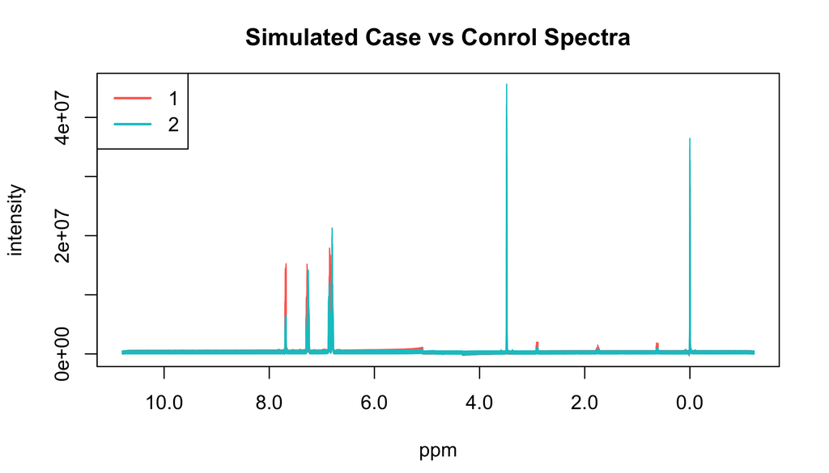

```r
# plot of all spectra
drawSpecPPM(Y.spec = Spectra,
            X.ppm = PPMvector,
            groupFactor = as.factor(ClassVector),
            title = 'Simulated Case vs Conrol Spectra',
            legend.extra.x = 1,
            legend.extra.y = 1.1)
```

### From spectra via peaks to grouped peaks (features)

Now that we’ve had a look at the spectra it is time to convert these to peaks by using the `getWaveletPeaks()` function.

```r
Peaks = speaq::getWaveletPeaks(Y.spec = SimulatedDataSet$Spectra,
                               X.ppm = SimulatedDataSet$PPMvector,
                               baselineThresh = median(SimulatedDataSet$Spectra)  )
```

The next steps are grouping and filling.

```r
Groups = speaq::PeakGrouper(Y.peaks = Peaks)

Filled = speaq::PeakFilling(Y.grouped = Groups,
                            Y.spec = Spectra)
```

With the peak filled data we can construct the feature matrix. This matrix can in turn be handed to the `relevant.features.p()` function which asigns a p-value to each feature. This p-value indicates which features are associated with the outcome vector.

```r
Features <- BuildFeatureMatrix(Filled)


SignificantFeatures <- speaq::relevant.features.p(Features,
                                                as.factor(ClassVector),
                                                p.adj = "none")
```

### Performance analysis

Since this is a simulated dataset for which a ground truth is known, we can evaluate the performance of the workflow. The question is whether speaq can clasify the interesting from the non intersesting peaks. Before we can evalueta the performance we must identify which peaks are relevant. These can be found in the `GroundTruthPeaks` object.

```r
## adding ppm values
SignificantFeatures$ppm = PPMvector[SignificantFeatures$index]

## finding relevant peaks
truepeaks_index = RANN::nn2(SignificantFeatures$ppm, query = GroundTruthPeaks, k = 1)
labels_speaq = rep(FALSE, nrow(SignificantFeatures))
labels_speaq[truepeaks_index$nn.idx] = TRUE
SignificantFeatures$truefeats = labels_speaq
```

Now we have the labels which indicate the interesting peaks from the non interesting peaks. We obtained these with a nearest neighbour search between the ppm values of speaq peaks and the ppm values of the ground truth peaks. Now we can plot the performance by means of an ROC curve. Note that the decision values to be used in the calculation of the ROC curve are calculated as 1 minus the p.values (since low p-values indicate a high decision value).

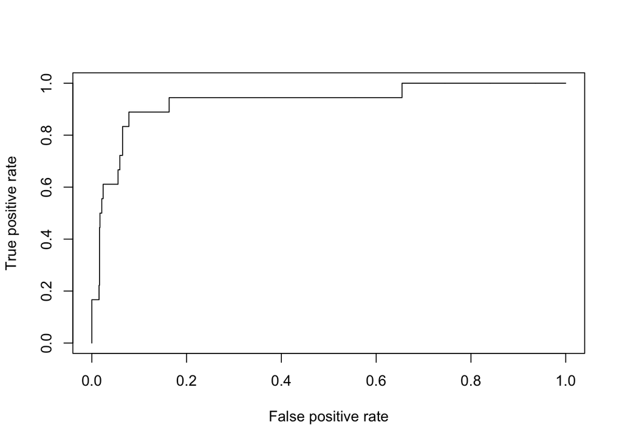

```r
pred <- ROCR::prediction(1-SignificantFeatures$p.values,SignificantFeatures$truefeats)
perf <- ROCR::performance(pred,"tpr","fpr")
ROCR::plot(perf)
```